# Homework 7

Alison Hall

2/26/2020

*Hypothesis*

- Long acclimitization time to lowered salinity levels will allow urchins to right themselves more quickly after experiencing a sudden low salinity event
- If this is the case we would expect that there would be a negative correlation after running a linear regression, meaning that as acclimation time decreases, righting time increases.
- Independent variable- acclimatin time (continuous, real number) +Dependent variable- righting time (continuous real number)

*Generation of Fake Data assuming a normal distribution in conditions where my hypothesis was true*

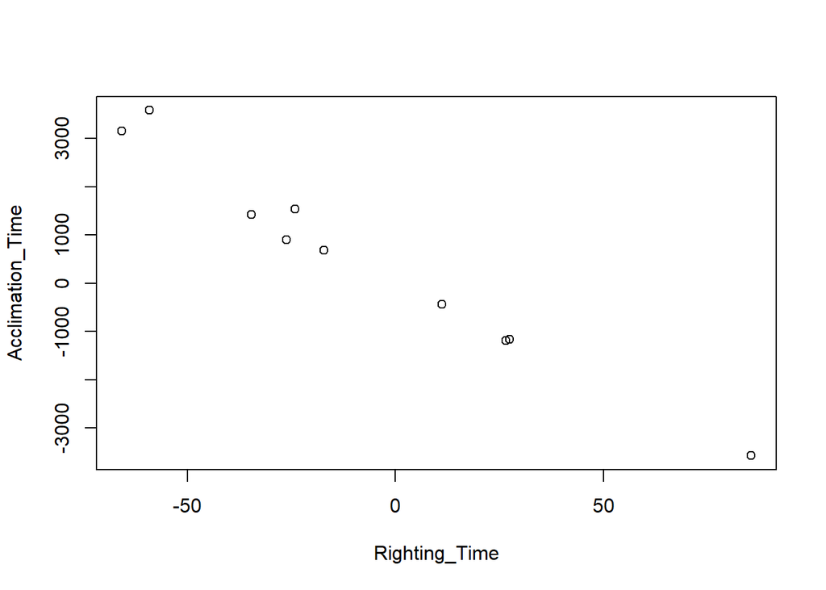

```r
library(ggplot2)
Righting_Time <- rnorm(n=10,mean=5,sd=50)
noise <- rnorm(n=10,sd=100) #to add the noise into the relatioship so it isnt exactly linear. Changing the sd makes the data more noisy. n has to be the same in both to ensure that x and y are the same length
Acclimation_Time <- 5 - Righting_Time*rnorm(n=10, mean=48, sd=10) + noise
plot(Righting_Time,Acclimation_Time)
```

*Make a tibble to organize these data*

```r
library(dplyr)
UrchinTibble <-tibble(Righting_Time,
                      Acclimation_Time)
```

*Regression for these data*

```r
regression <- lm(Acclimation_Time ~ Righting_Time, UrchinTibble)
print(regression)
```

```
##
## Call:
## lm(formula = Acclimation_Time ~ Righting_Time, data = UrchinTibble)
##
## Coefficients:
##   (Intercept)  Righting_Time
##        140.63         -46.46
```

```r
summary(regression)
```

```
##
## Call:
## lm(formula = Acclimation_Time ~ Righting_Time, data = UrchinTibble)
##
## Residuals:
##     Min      1Q  Median      3Q     Max
## -454.65 -209.13  -52.07  187.24  698.79
##
## Coefficients:
##               Estimate Std. Error t value Pr(>|t|)
## (Intercept)    140.630    114.766   1.225    0.255
## Righting_Time  -46.463      2.602 -17.855 9.92e-08 ***
## ---
## Signif. codes:  0 '***' 0.001 '**' 0.01 '*' 0.05 '.' 0.1 ' ' 1
##
## Residual standard error: 357.4 on 8 degrees of freedom
## Multiple R-squared:  0.9755, Adjusted R-squared:  0.9725
## F-statistic: 318.8 on 1 and 8 DF,  p-value: 9.919e-08
```

*Plot these data*

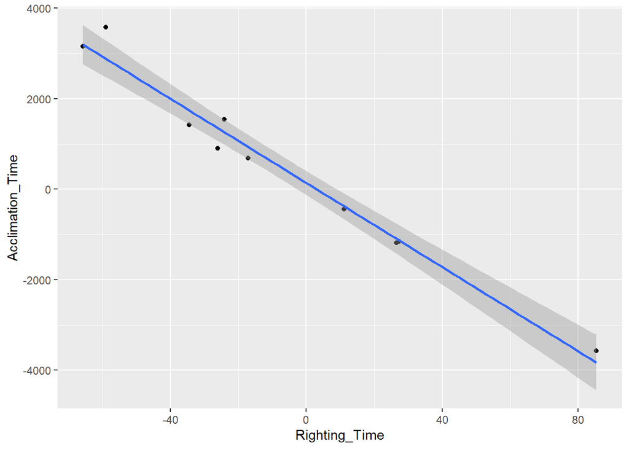

```r
RegressionPlot <- ggplot(data=UrchinTibble, aes (x=Righting_Time,y=Acclimation_Time))+geom_point()+stat_smooth(method = lm)
print(RegressionPlot)
```

*Adjusting the sample size*

- I adjusted the sample size between 10 and 100 and still observe a negative linear relationship with Pvalues below 0.05 which is what I expect should my hypothesis be correct and suggests that I could still run my experiment even with just a few sea urchins.

*Adjusting the standard deviation*

- I adjusted the standard deviation in the noise that was added into the independent variable and the sd of the dependent variable. I notice when I adjusted the standard deviation of the noise the linear relationship was less tight. When the standard deviation of the noise was 200+ I began to observe an insignificant P value. This means that the relationship is fairly strong in the face of noise.
- When I adjusted the noise of the random number that the independent variable is multiplied by as well as the sd in the noise, the p value quickly increases to become insiginificant